# R Notebook

```r
library(tidyverse)
```

```r
avocado <- read_csv("data/avocado.csv")
avocado
```

| X1 | Date | AveragePrice | Total Volume | 4046 | 4225 | 4770 | Total Bags | Small Bags | Large Bags | XLarge Bags | type | year | region |
| --- | --- | --- | --- | --- | --- | --- | --- | --- | --- | --- | --- | --- | --- |
| 0 | 2015-12-27 | 1.33 | 64236.62 | 1036.74 | 54454.85 | 48.16 | 8696.87 | 8603.62 | 93.25 | 0.00 | conventional | 2015 | Albany |
| 1 | 2015-12-20 | 1.35 | 54876.98 | 674.28 | 44638.81 | 58.33 | 9505.56 | 9408.07 | 97.49 | 0.00 | conventional | 2015 | Albany |
| 2 | 2015-12-13 | 0.93 | 118220.22 | 794.70 | 109149.67 | 130.50 | 8145.35 | 8042.21 | 103.14 | 0.00 | conventional | 2015 | Albany |
| 3 | 2015-12-06 | 1.08 | 78992.15 | 1132.00 | 71976.41 | 72.58 | 5811.16 | 5677.40 | 133.76 | 0.00 | conventional | 2015 | Albany |
| 4 | 2015-11-29 | 1.28 | 51039.60 | 941.48 | 43838.39 | 75.78 | 6183.95 | 5986.26 | 197.69 | 0.00 | conventional | 2015 | Albany |
| 5 | 2015-11-22 | 1.26 | 55979.78 | 1184.27 | 48067.99 | 43.61 | 6683.91 | 6556.47 | 127.44 | 0.00 | conventional | 2015 | Albany |
| 6 | 2015-11-15 | 0.99 | 83453.76 | 1368.92 | 73672.72 | 93.26 | 8318.86 | 8196.81 | 122.05 | 0.00 | conventional | 2015 | Albany |
| 7 | 2015-11-08 | 0.98 | 109428.33 | 703.75 | 101815.36 | 80.00 | 6829.22 | 6266.85 | 562.37 | 0.00 | conventional | 2015 | Albany |
| 8 | 2015-11-01 | 1.02 | 99811.42 | 1022.15 | 87315.57 | 85.34 | 11388.36 | 11104.53 | 283.83 | 0.00 | conventional | 2015 | Albany |
| 9 | 2015-10-25 | 1.07 | 74338.76 | 842.40 | 64757.44 | 113.00 | 8625.92 | 8061.47 | 564.45 | 0.00 | conventional | 2015 | Albany |

[output cut: 990 more lines]

I am checking here whether there is any missing values in the dataset. There are in fact zero N/A’s - see below.

```r
summary(avocado)
```

```
       X1             Date             AveragePrice    Total Volume
 Min.   : 0.00   Min.   :2015-01-04   Min.   :0.440   Min.   :      85
 1st Qu.:10.00   1st Qu.:2015-10-25   1st Qu.:1.100   1st Qu.:   10839
 Median :24.00   Median :2016-08-14   Median :1.370   Median :  107377
 Mean   :24.23   Mean   :2016-08-13   Mean   :1.406   Mean   :  850644
 3rd Qu.:38.00   3rd Qu.:2017-06-04   3rd Qu.:1.660   3rd Qu.:  432962
 Max.   :52.00   Max.   :2018-03-25   Max.   :3.250   Max.   :62505647
      4046               4225               4770           Total Bags
 Min.   :       0   Min.   :       0   Min.   :      0   Min.   :       0
 1st Qu.:     854   1st Qu.:    3009   1st Qu.:      0   1st Qu.:    5089
 Median :    8645   Median :   29061   Median :    185   Median :   39744
 Mean   :  293008   Mean   :  295155   Mean   :  22840   Mean   :  239639
 3rd Qu.:  111020   3rd Qu.:  150207   3rd Qu.:   6243   3rd Qu.:  110783
 Max.   :22743616   Max.   :20470573   Max.   :2546439   Max.   :19373134
   Small Bags         Large Bags       XLarge Bags           type
 Min.   :       0   Min.   :      0   Min.   :     0.0   Length:18249
 1st Qu.:    2849   1st Qu.:    127   1st Qu.:     0.0   Class :character
 Median :   26363   Median :   2648   Median :     0.0   Mode  :character
 Mean   :  182195   Mean   :  54338   Mean   :  3106.4
 3rd Qu.:   83338   3rd Qu.:  22029   3rd Qu.:   132.5
 Max.   :13384587   Max.   :5719097   Max.   :551693.7
      year         region
 Min.   :2015   Length:18249
 1st Qu.:2015   Class :character
 Median :2016   Mode  :character
 Mean   :2016
 3rd Qu.:2017
 Max.   :2018
```

```r
library(GGally)
```

In an effort to reduce the amount of variables, I am going to exclude index, the bag sizes (because we have no information about how much they hold), the year and the region. I am going to add two variables: month (to try to correlate any cyclical element to average price), other_avocados: for the the remainder avocados not listed under the 3 PLU codes.

```r
library(lubridate)
```

```r
library(janitor)
```

```r
avocado <- clean_names(avocado)
```

```r
avocado
```

| x1 | date | average_price | total_volume | x4046 | x4225 | x4770 | total_bags | small_bags | large_bags | x_large_bags | type | year | region |
| --- | --- | --- | --- | --- | --- | --- | --- | --- | --- | --- | --- | --- | --- |
| 0 | 2015-12-27 | 1.33 | 64236.62 | 1036.74 | 54454.85 | 48.16 | 8696.87 | 8603.62 | 93.25 | 0.00 | conventional | 2015 | Albany |
| 1 | 2015-12-20 | 1.35 | 54876.98 | 674.28 | 44638.81 | 58.33 | 9505.56 | 9408.07 | 97.49 | 0.00 | conventional | 2015 | Albany |
| 2 | 2015-12-13 | 0.93 | 118220.22 | 794.70 | 109149.67 | 130.50 | 8145.35 | 8042.21 | 103.14 | 0.00 | conventional | 2015 | Albany |
| 3 | 2015-12-06 | 1.08 | 78992.15 | 1132.00 | 71976.41 | 72.58 | 5811.16 | 5677.40 | 133.76 | 0.00 | conventional | 2015 | Albany |
| 4 | 2015-11-29 | 1.28 | 51039.60 | 941.48 | 43838.39 | 75.78 | 6183.95 | 5986.26 | 197.69 | 0.00 | conventional | 2015 | Albany |
| 5 | 2015-11-22 | 1.26 | 55979.78 | 1184.27 | 48067.99 | 43.61 | 6683.91 | 6556.47 | 127.44 | 0.00 | conventional | 2015 | Albany |
| 6 | 2015-11-15 | 0.99 | 83453.76 | 1368.92 | 73672.72 | 93.26 | 8318.86 | 8196.81 | 122.05 | 0.00 | conventional | 2015 | Albany |
| 7 | 2015-11-08 | 0.98 | 109428.33 | 703.75 | 101815.36 | 80.00 | 6829.22 | 6266.85 | 562.37 | 0.00 | conventional | 2015 | Albany |
| 8 | 2015-11-01 | 1.02 | 99811.42 | 1022.15 | 87315.57 | 85.34 | 11388.36 | 11104.53 | 283.83 | 0.00 | conventional | 2015 | Albany |
| 9 | 2015-10-25 | 1.07 | 74338.76 | 842.40 | 64757.44 | 113.00 | 8625.92 | 8061.47 | 564.45 | 0.00 | conventional | 2015 | Albany |

[output cut: 990 more lines]

```r
avocado_trim <- avocado %>%
  mutate(month = month(date)) %>%
  mutate(other_avocados = (total_volume - (x4046 + x4225 + x4770))) %>%
  select(month, average_price, x4046, x4225, x4770, other_avocados, type, month)
```

```r
avocado_trim
```

| month | average_price | x4046 | x4225 | x4770 | other_avocados | type |
| --- | --- | --- | --- | --- | --- | --- |
| 12 | 1.33 | 1036.74 | 54454.85 | 48.16 | 8696.87 | conventional |
| 12 | 1.35 | 674.28 | 44638.81 | 58.33 | 9505.56 | conventional |
| 12 | 0.93 | 794.70 | 109149.67 | 130.50 | 8145.35 | conventional |
| 12 | 1.08 | 1132.00 | 71976.41 | 72.58 | 5811.16 | conventional |
| 11 | 1.28 | 941.48 | 43838.39 | 75.78 | 6183.95 | conventional |
| 11 | 1.26 | 1184.27 | 48067.99 | 43.61 | 6683.91 | conventional |
| 11 | 0.99 | 1368.92 | 73672.72 | 93.26 | 8318.86 | conventional |
| 11 | 0.98 | 703.75 | 101815.36 | 80.00 | 6829.22 | conventional |
| 11 | 1.02 | 1022.15 | 87315.57 | 85.34 | 11388.36 | conventional |
| 10 | 1.07 | 842.40 | 64757.44 | 113.00 | 8625.92 | conventional |

[output cut: 990 more lines]

Now I will plot some visualisation to see if I can identify some variable relationships for average_price

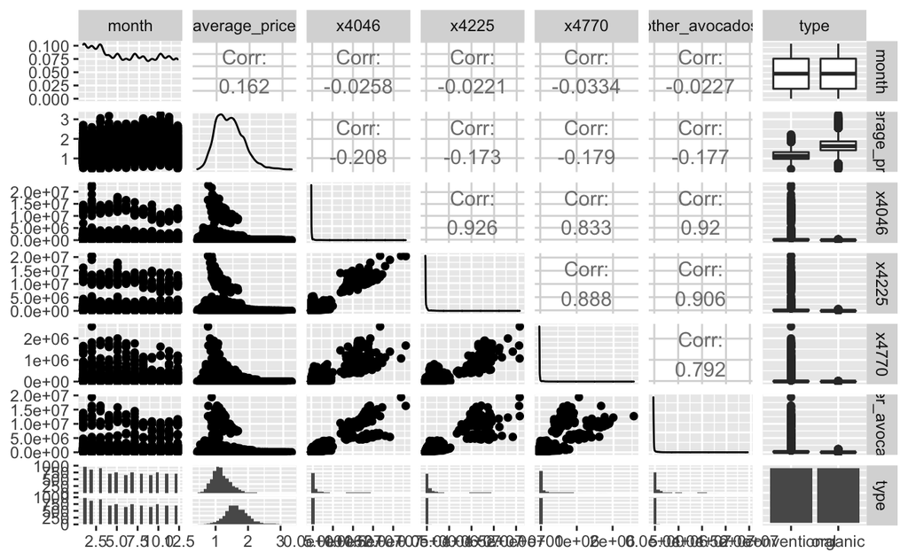

```r
ggpairs(avocado_trim)
```

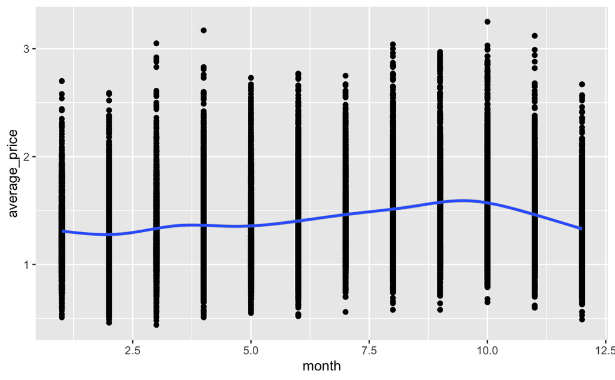

```r
avocado_trim %>%
  ggplot(aes(x = month, y = average_price)) +
  geom_point() +
  geom_smooth()
```

The graph above is not conclusive because prices seem to stretch up and down but there is a suggestion that apart from some outliers, average price peaks around the end of summer (Aug) to early Autumn (Sep/Oct)

So I will build the model with average price and month

```r
avocado_mod1 <- lm(average_price ~ month, data = avocado_trim)
```

```r
summary(avocado_mod1)
```

```
Call:
lm(formula = average_price ~ month, data = avocado_trim)

Residuals:
     Min       1Q   Median       3Q      Max
-1.02373 -0.30018 -0.03018  0.25431  1.80431

Coefficients:
             Estimate Std. Error t value Pr(>|t|)
(Intercept) 1.2916708  0.0059231  218.07   <2e-16 ***
month       0.0185047  0.0008323   22.23   <2e-16 ***
---
Signif. codes:  0 ‘***’ 0.001 ‘**’ 0.01 ‘*’ 0.05 ‘.’ 0.1 ‘ ’ 1

Residual standard error: 0.3973 on 18247 degrees of freedom
Multiple R-squared:  0.02638,   Adjusted R-squared:  0.02632
F-statistic: 494.3 on 1 and 18247 DF,  p-value: < 2.2e-16
```

The R squared figure isn’t high but it wasn’t when we originally plotted it.

I will now plot against the regression comparisons.

Residuals vs fitted is around nil which is correct. Normal Q-Q is following the dotted line which is also a good correlation. Scale-Location is relatively flat which is also good and not indicating a trend.

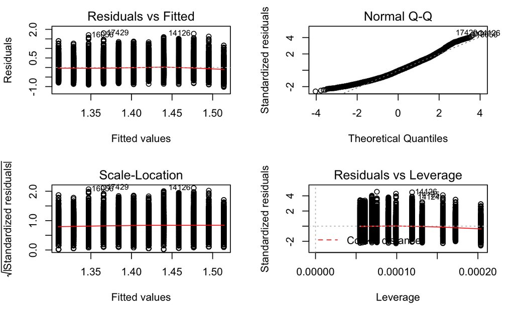

```r
par(mfrow = c(2,2))
plot(avocado_mod1)
```

I am inclined to add all the avocado PLU’s together (but separate) into the model to distinguinsdh between them.

```r
avocado_mod2 <- lm(average_price ~ month + x4046 + x4225 + x4770 + other_avocados, data = avocado_trim)
```

```r
summary(avocado_mod2)
```

```
Call:
lm(formula = average_price ~ month + x4046 + x4225 + x4770 +
    other_avocados, data = avocado_trim)

Residuals:
     Min       1Q   Median       3Q      Max
-0.97093 -0.29011 -0.03615  0.24699  1.78589

Coefficients:
                 Estimate Std. Error t value Pr(>|t|)
(Intercept)     1.313e+00  5.842e-03 224.813  < 2e-16 ***
month           1.773e-02  8.129e-04  21.817  < 2e-16 ***
x4046          -1.108e-07  7.027e-09 -15.772  < 2e-16 ***
x4225           6.631e-08  8.157e-09   8.129 4.60e-16 ***
x4770          -3.436e-07  5.855e-08  -5.869 4.47e-09 ***
other_avocados  1.625e-08  8.022e-09   2.026   0.0428 *
---
Signif. codes:  0 ‘***’ 0.001 ‘**’ 0.01 ‘*’ 0.05 ‘.’ 0.1 ‘ ’ 1

Residual standard error: 0.3878 on 18243 degrees of freedom
Multiple R-squared:  0.07292,   Adjusted R-squared:  0.07266
F-statistic:   287 on 5 and 18243 DF,  p-value: < 2.2e-16
```

```r
avocado_mod3 <- lm(average_price ~ month + x4046 + x4225 + x4770, data = avocado_trim)

summary(avocado_mod3)
```

```
Call:
lm(formula = average_price ~ month + x4046 + x4225 + x4770, data = avocado_trim)

Residuals:
    Min      1Q  Median      3Q     Max
-0.9765 -0.2903 -0.0362  0.2477  1.7856

Coefficients:
              Estimate Std. Error t value Pr(>|t|)
(Intercept)  1.314e+00  5.840e-03 224.924  < 2e-16 ***
month        1.773e-02  8.129e-04  21.811  < 2e-16 ***
x4046       -1.035e-07  6.029e-09 -17.170  < 2e-16 ***
x4225        7.228e-08  7.608e-09   9.500  < 2e-16 ***
x4770       -3.565e-07  5.820e-08  -6.125 9.25e-10 ***
---
Signif. codes:  0 ‘***’ 0.001 ‘**’ 0.01 ‘*’ 0.05 ‘.’ 0.1 ‘ ’ 1

Residual standard error: 0.3878 on 18244 degrees of freedom
Multiple R-squared:  0.07271,   Adjusted R-squared:  0.07251
F-statistic: 357.6 on 4 and 18244 DF,  p-value: < 2.2e-16
```

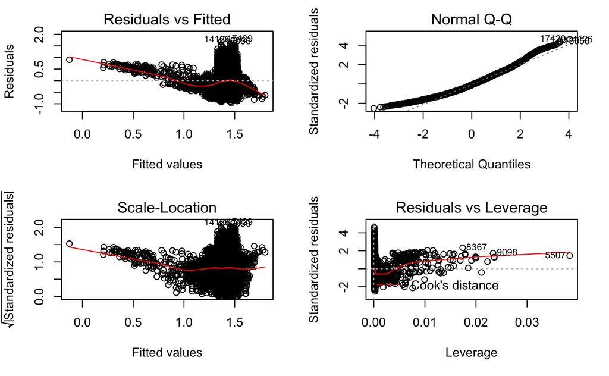

```r
par(mfrow = c(2,2))
plot(avocado_mod3)
```

Unfortunately model 3 does not show peomise with the residulas vs fotted as the trend is moving away from nil. The scale location has a definite trend downwards which is also not helpful. The Mormal Q-Q graph follows the odtted line.

And here are answer to the quiz on regaressionn models:

1. overfitting
2. the one with the score of 33,559
3. the one with an adjusted r squared value of 0.43
4. No
5. it goes through each iteration testing one and using the rest as control subjects.
6. It’s a data set that has been cleaned for use in the refgrssion analysis
9. Keep it simple, make it as uncomplicated as possible, include commentary and justifciation
10. log
16. To show that you are applying your knowledge and adding value